# 实验记录文档2

Huanghaicheng

2021-10-28

# 1 回顾

足球点球大战中，ABBA的罚球顺序会不会比ABAB的罚球顺序更公平？不妨通过马氏链的方法来进行随机模拟研究一下。

# 2 反思

对上一个模型进行进一步探讨。

## 2.1 模型建立

先确定状态空间。假设每一次罚球的比分为一个状态，形式上来说就是一个二元组$(x,y)$，离散但可能无限？为了方便，不妨假设状态为一个三元组$(n,x,y)$，其中$n$为轮次（一个轮次两次罚球），$x$为第一轮先罚一方（下面指A队）比分，$y$为第一轮后罚一方（下面指B队）比分。

然后确定转移概率，只依赖于上一个状态也就是上一次罚球的比分，这里做一个重要的假设，**领先一方更有可能继续进球，落后一方更有可能罚丢**。假设$p_1$为平局状态转为进球状态的概率，$p_2$为领先一方进球概率，$p_3$为落后一方进球概率，三者为固定值，这个假设表示$p_2>p_1,p_3<p_1$。

## 2.2 模拟实验

定义模拟函数：

```r
pk.sim.1 <- function(n=10000,p1=0.6,p2=0.8,p3=0.5,draw=FALSE){
  ## 定义一些函数

  # 判断是否点球结束
  pk.end <- function(s){
    # 前三轮3-0
    if(s[[1]]==3 & abs(s[[3]]-s[[2]])==3) return(TRUE)
    # 前四轮分差大于1
    if(s[[1]]==4 & abs(s[[3]]-s[[2]])>1) return(TRUE)
    # 后面的所有轮次只要比分不同就结束
    if(s[[1]]>4 & s[[3]]!=s[[2]]) return(TRUE)

    # 其余一律未结束
    return(FALSE)
  }

  # 状态转移
  pk.trans <- function(s, team=c("A","B")){
    p <- runif(1)

    # A队罚球
    if(team=="A"){
      # 打平
      if(s[[2]]==s[[3]]){
        if(p<p1) s[[2]] = s[[2]]+1  # 进球
      }
      # 领先
      else if(s[[2]]>s[[3]]){
        if(p<p2) s[[2]] = s[[2]]+1  # 进球
      }
      # 落后
      else{
        if(p<p3) s[[2]] = s[[2]]+1  # 进球
      }
    }
    # B队罚球
    else{
      # 打平
      if(s[[2]]==s[[3]]){
        if(p<p1) s[[3]] = s[[3]]+1  # 进球
      }
      # 领先
      else if(s[[3]]>s[[2]]){
        if(p<p2) s[[3]] = s[[3]]+1  # 进球
      }
      # 落后
      else{
        if(p<p3) s[[3]] = s[[3]]+1  # 进球
      }
    }
    return(s)
  }

  # 单次模拟
  pk.ABAB <- function(){
    s <- c(0,0,0)  # 初始化状态
    while (!pk.end(s)) {
      s[[1]] <- s[[1]]+1

      # A队先罚
      s <- pk.trans(s,team = "A")

      # B队后罚
      s <- pk.trans(s,team = "B")
    }
    return(s[[2]]>s[[3]])
  }
  pk.ABBA <- function(){
    s <- c(0,0,0)  # 初始化状态
    while (!pk.end(s)) {
      s[[1]] <- s[[1]]+1

      # 奇数轮，也就是AB
      if(s[[1]]%%2){
        # A队先罚
        s <- pk.trans(s,team = "A")

        # B队后罚
        s <- pk.trans(s,team = "B")
      }
      # 偶数轮，也即BA
      else{
        # B队先罚
        s <- pk.trans(s,team = "B")

        # A队先罚
        s <- pk.trans(s,team = "A")
      }
    }
    return(s[[2]]>s[[3]])
  }

  ## 开始多次模拟
  r1 <- vector("logical",n)
  r2 <- vector("logical",n)
  for (i in 1:n) {
    r1[[i]] <- pk.ABAB()
    r2[[i]] <- pk.ABBA()
  }

  ## 绘图
  if(draw){
    library(tidyverse)
    y1 <- accumulate(r1,`+`)/(1:n)
    y2 <- accumulate(r2,`+`)/(1:n)
    draw <- tibble(x=1:n,y1=y1,y2=y2) %>%
      ggplot(aes(x=x))+
      geom_line(aes(y=y1,color=paste("ABAB,mean=",y1[[n]])))+
      geom_line(aes(y=y2,color=paste("ABBA,mean=",y2[[n]])))+
      labs(color="color",x="Simulation times",y="Ergodic mean",
           caption = paste("p1=",p1,",p2=",p2,",p3=",p3,sep = ""))
  }

  return(list(m1=mean(r1),m2=mean(r2),draw=draw))
}
```

对$p_1,p_2,p_3$进行组合模拟：

```r
p1=seq(0.5,0.9,0.01)
p2=seq(0.5,0.9,0.01)
p3=seq(0.5,0.9,0.01)
tb2 <- crossing(p1,p2,p3) %>%
  filter(p2>p1,p3<p1,p2-p1<0.05,p1-p3<0.05)  # 领先一方进球概率提高，落后一方进球概率下降
head(tb2)
```

```
## # A tibble: 6 x 3
##      p1    p2    p3
##   <dbl> <dbl> <dbl>
## 1  0.51  0.52  0.5
## 2  0.51  0.53  0.5
## 3  0.51  0.54  0.5
## 4  0.51  0.55  0.5
## 5  0.52  0.53  0.5
## 6  0.52  0.53  0.51
```

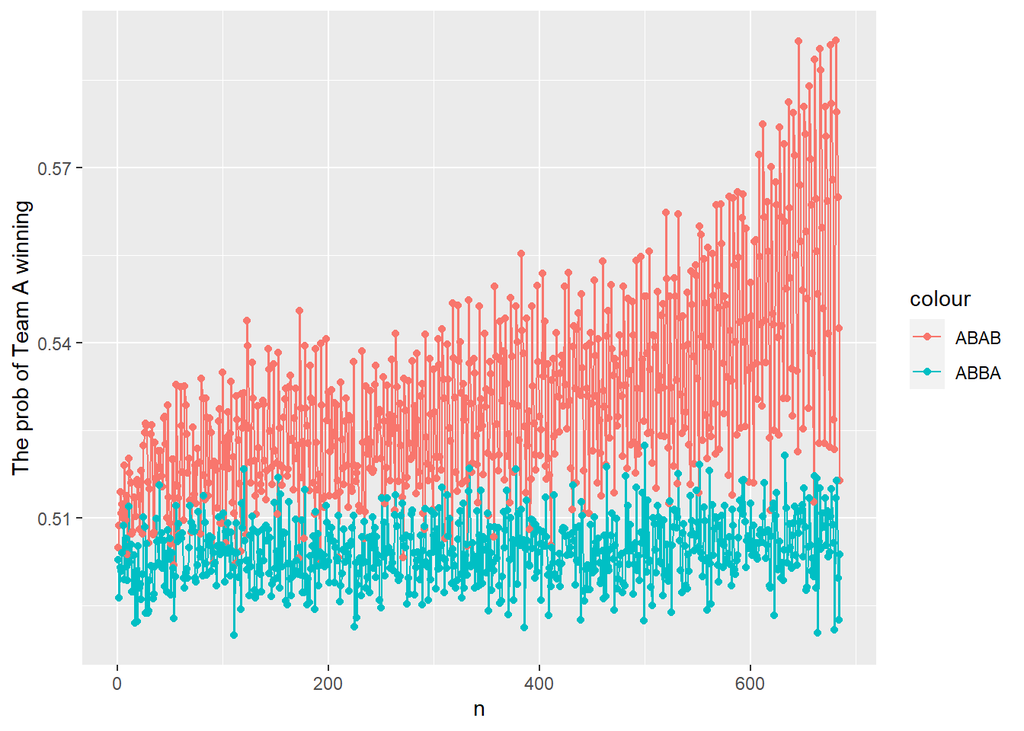

```r
r <- pmap(tb2,pk.sim.1)
draw <- map(r,"draw")
m1 <- map_dbl(r,"m1")
m2 <- map_dbl(r,"m2")

tb3 <- tb2 %>%
  mutate(m1=m1,m2=m2,n=1:n())
tb3 %>% ggplot(aes(x=n))+
  geom_line(aes(y=m1,color="ABAB"))+
  geom_line(aes(y=m2,color="ABBA"))+
  geom_point(aes(y=m1,color="ABAB"))+
  geom_point(aes(y=m2,color="ABBA"))+
  labs(y="The prob of Team A winning")
```

通过上图可以看到，对于大部分的$(p_1,p_2,p_3)$组合，ABBA都比ABAB的A队胜率更接近0.5，也即是更公平。这里我取的组合为：
$$\{(p_1,p_2,p_3):p_i=0.5,0.51.\cdots,0.9,0<p_2-p_1<0.05,0<p_1-p_3<0.05\}$$

## 2.3 修正

还是上图的数据，这里我修正一下图像：

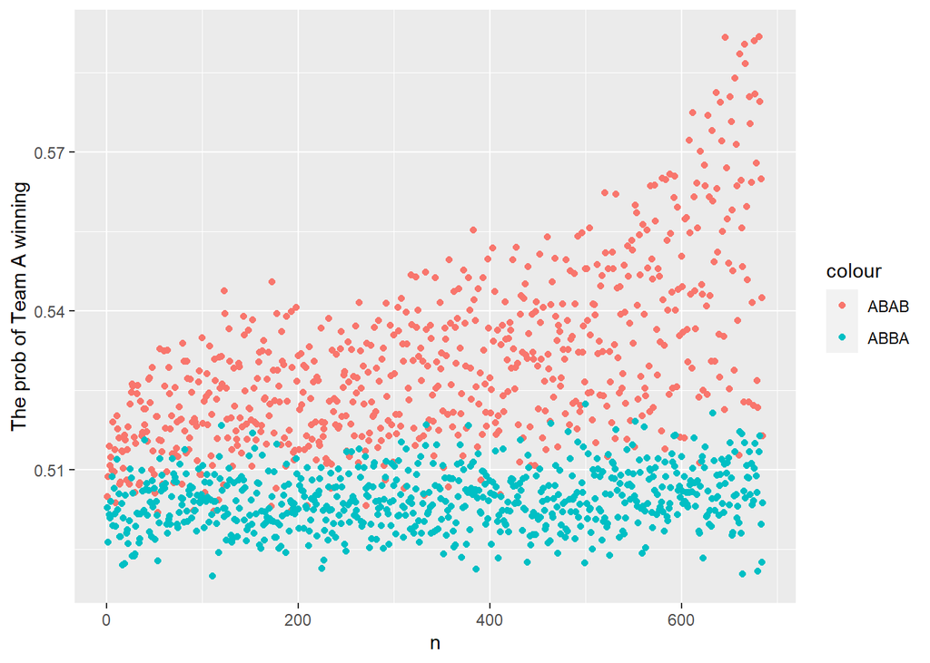

```r
tb3 %>%
  ggplot(aes(x=n))+
  geom_point(aes(y=m1,color="ABAB"))+
  geom_point(aes(y=m2,color="ABBA"))+
  labs(y="The prob of Team A winning")
```

这里面`n`的变化指的是，先是`p3`循环取值，再是`p2`，后是`p1`。接下来探讨的是随着`n`的增大，两种规则下散点图所表现出来的趋势。

对`p1`分组，求对应`m1`（ABAB规则下A队胜率），`m2`（ABBA规则下A队胜率）的均值跟方差进行对比：

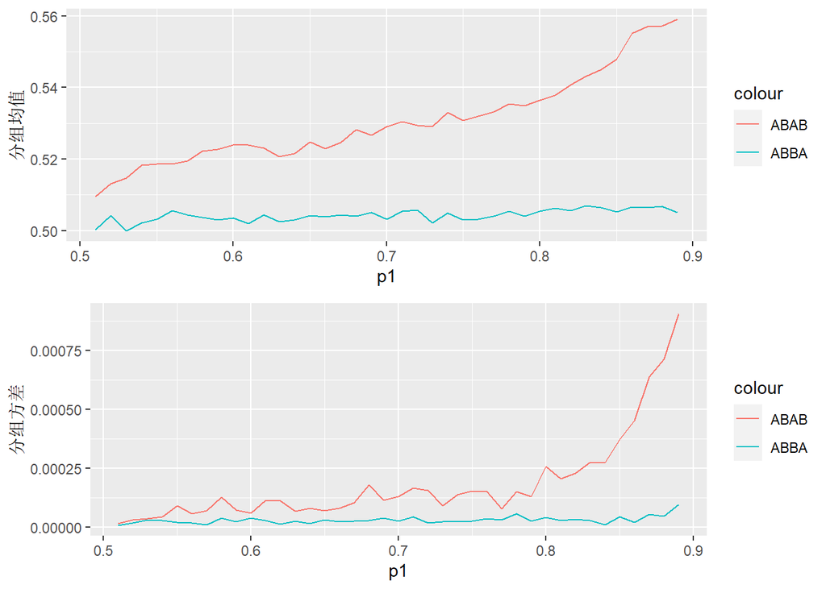

```r
p1 <- tb3 %>%
  group_by(p1) %>%
  summarise(mean1=mean(m1),mean2=mean(m2)) %>%
  ggplot()+
  geom_line(aes(p1,mean1,color="ABAB"))+
  geom_line(aes(p1,mean2,color="ABBA"))+
  labs(y="分组均值")
p2 <- tb3 %>%
  group_by(p1) %>%
  summarise(d1=var(m1),d2=var(m2)) %>%
  ggplot()+
  geom_line(aes(p1,d1,color="ABAB"))+
  geom_line(aes(p1,d2,color="ABBA"))+
  labs(y="分组方差")
grid.arrange(p1,p2,nrow=2)
```

通过上面两幅图，可以得到随着`p1`的增大，ABAB规则下A队胜率均值逐渐增大，方差也逐渐增大，而ABBA规则下A队胜率均值跟方差变动不大。这解释了散点图中的趋势。

接下来观察`m1` `m2`跟参数`p1` `p2` `p3`的关系。由于前面的参数离散化做得并不好，为了节省计算资源截断了很多数据，这里重新离散化参数进行模拟。

不妨先假设$p_1=0.7$，对满足条件的`p2` `p3`离散化并模拟：

```r
p1=0.7
p2=seq(0.5,0.9,0.01)
p3=seq(0.5,0.9,0.01)
tb6 <- crossing(p1,p2,p3) %>%
  filter(p2>p1,p3<p1)  # 领先一方进球概率提高，落后一方进球概率下降
head(tb6)
```

```
## # A tibble: 6 x 3
##      p1    p2    p3
##   <dbl> <dbl> <dbl>
## 1   0.7  0.71  0.5
## 2   0.7  0.71  0.51
## 3   0.7  0.71  0.52
## 4   0.7  0.71  0.53
## 5   0.7  0.71  0.54
## 6   0.7  0.71  0.55
```

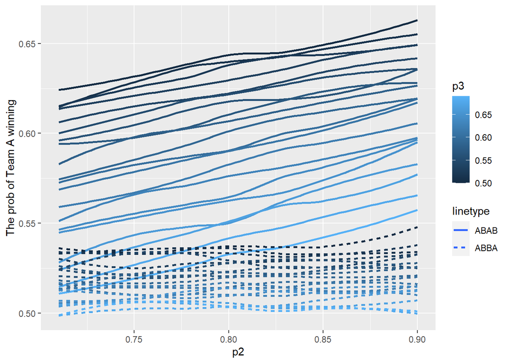

```r
r <- pmap(tb6,pk.sim.1)
draw <- map(r,"draw")
m1 <- map_dbl(r,"m1")
m2 <- map_dbl(r,"m2")

tb6 <- tb6 %>%
  mutate(m1=m1,m2=m2,n=1:n())


tb6 %>%
  ggplot()+
  geom_smooth(aes(p2,m1,group=p3,color=p3,linetype="ABAB"),se = FALSE)+
  geom_smooth(aes(p2,m2,group=p3,color=p3,linetype="ABBA"),se = FALSE)+
  labs(y="The prob of Team A winning")
```

这表明了，ABAB规则下，A队胜率随着$p_2$的增大或$p_3$的减小而上升，也即是领先时进球率越高、落后时进球率越低（实际上就表示领先一方比落后一方有更明显的优势），A队胜率越高；ABBA规则下，A队胜率只对$p_3$的减小有小幅度的上升，并且始终在0.5-0.55附近，这表明ABBA比ABAB对于领先优势有更好的包容性，由于ABAB规则下A队更有可能获得领先优势，从而导致A队更有可能获胜，公平性不如ABBA规则。

取$p_1=0.6,0.7,0.8$，类似地按照上面的做法绘图：

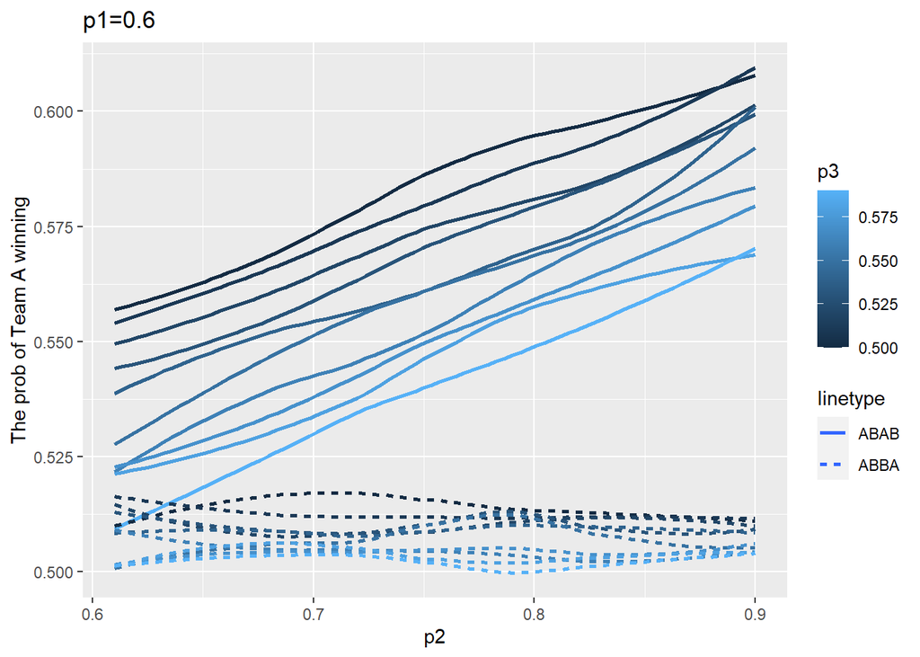

```r
p1=c(0.6,0.7,0.8)
p2=seq(0.5,0.9,0.01)
p3=seq(0.5,0.9,0.01)
tb7 <- crossing(p1,p2,p3) %>%
  filter(p2>p1,p3<p1)  # 领先一方进球概率提高，落后一方进球概率下降

r <- pmap(tb7,pk.sim.1)
m1 <- map_dbl(r,"m1")
m2 <- map_dbl(r,"m2")

tb7 <- tb7 %>%
  mutate(m1=m1,m2=m2,n=1:n())


tb7 %>%
  filter(p1==0.6) %>%
  ggplot()+
  geom_smooth(aes(p2,m1,group=p3,color=p3,linetype="ABAB"),se = FALSE)+
  geom_smooth(aes(p2,m2,group=p3,color=p3,linetype="ABBA"),se = FALSE)+
  labs(y="The prob of Team A winning",title = "p1=0.6")
```

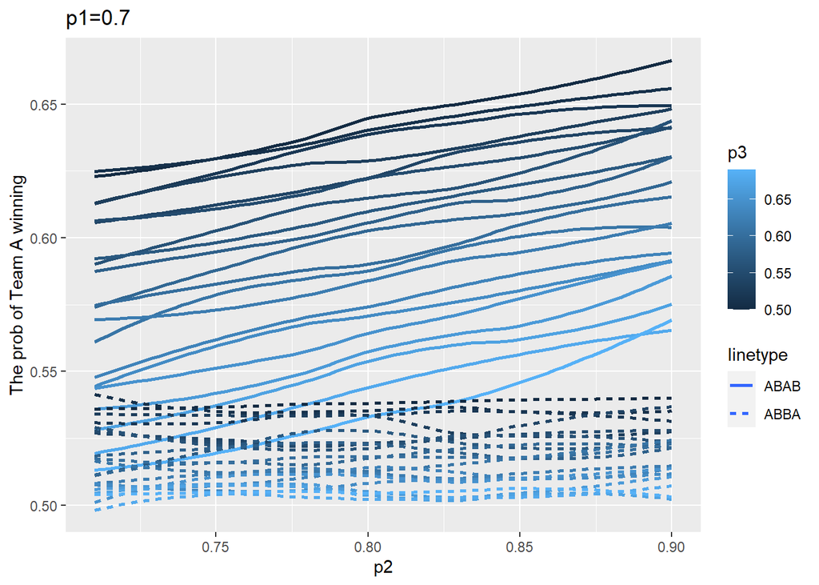

```r
tb7 %>%
  filter(p1==0.7) %>%
  ggplot()+
  geom_smooth(aes(p2,m1,group=p3,color=p3,linetype="ABAB"),se = FALSE)+
  geom_smooth(aes(p2,m2,group=p3,color=p3,linetype="ABBA"),se = FALSE)+
  labs(y="The prob of Team A winning",title = "p1=0.7")
```

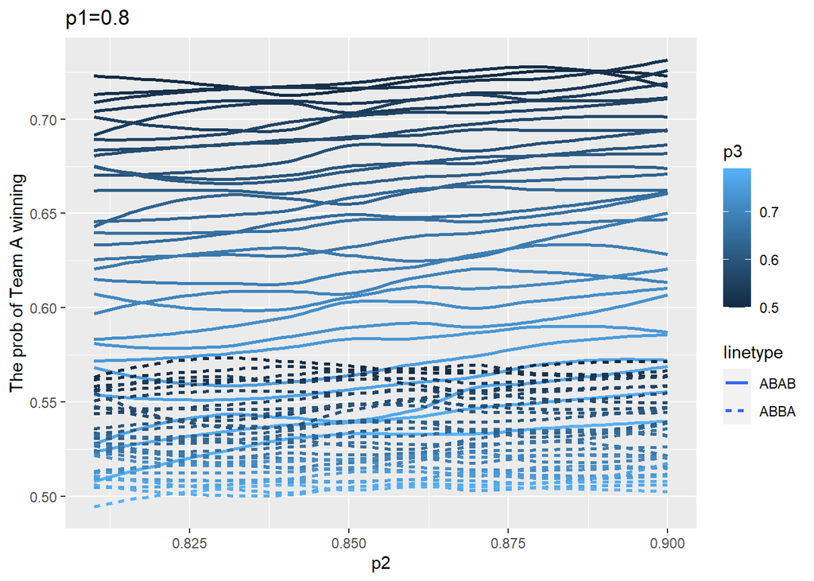

```r
tb7 %>%
  filter(p1==0.8) %>%
  ggplot()+
  geom_smooth(aes(p2,m1,group=p3,color=p3,linetype="ABAB"),se = FALSE)+
  geom_smooth(aes(p2,m2,group=p3,color=p3,linetype="ABBA"),se = FALSE)+
  labs(y="The prob of Team A winning",title = "p1=0.8")
```

可以看到，对于不同的$p_1$，对图像的趋势性影响不大，结论也跟前面一致。

# 3 新模型

## 3.1 模型建立

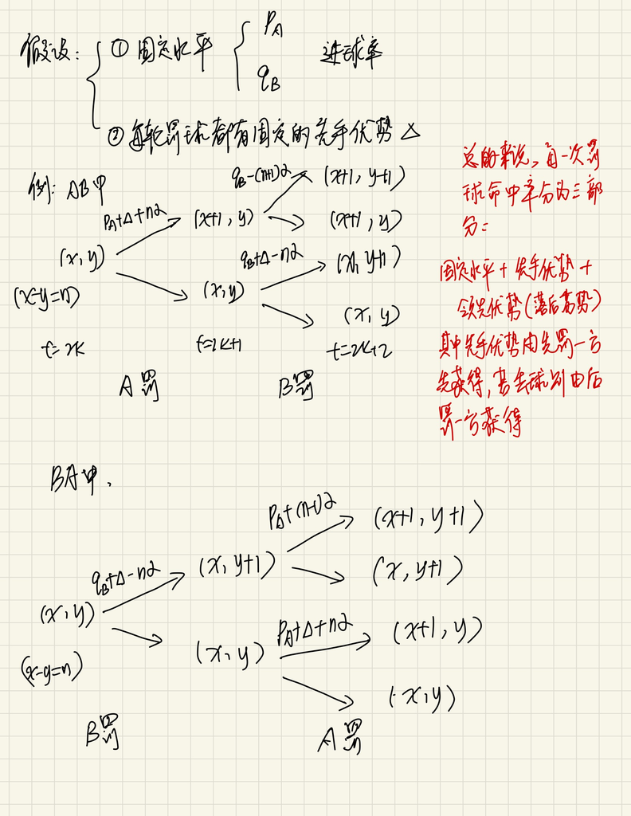

```r
knitr::include_graphics("model.jpg")
```

然后想谈谈一个很重要的问题：在这个模型下怎么定义**公平性**？

首先，是不是对于上面的任意参数$p_A,q_B,\Delta,\alpha$，某规则下A队胜率更接近0.5就说明该规则更公平？我认为不太恰当，例如当$p_A>q_B$时，特别是差得比较大的时候，最终点球结果依旧是五五开，这是不是偏袒了弱队？点球就会变成猜硬币比赛了（毕竟无论如何胜率都是五五开）。所以，我认为公平性应当刻画为对先手优势的包容性或者不敏感性，也即是在存在先手优势的情况下的A队胜率跟无先手优势的A队胜率应当相差不大，否则稍微极端地想（下文也有例子），假设在ABAB规则的某先手优势下A队胜率为1，那么点球就又会沦为猜硬币比赛了。

## 3.2 模拟实验的demo实现

定义一下参数跟函数：

```r
# 一些参数
p.A <- 0.7
q.B <- 0.68
delta <- 0.05
alpha <- 0.05

# 判断是否结束
# 传入状态三元组
pk.end <- function(s){
  # 前三轮3-0
  if(s[[1]]==3 & abs(s[[3]]-s[[2]])==3) return(TRUE)
  # 前四轮分差大于1
  if(s[[1]]==4 & abs(s[[3]]-s[[2]])>1) return(TRUE)
  # 后面的所有轮次只要比分不同就结束
  if(s[[1]]>4 & s[[3]]!=s[[2]]) return(TRUE)

  # 其余一律未结束
  return(FALSE)
}

# 状态转移
pk.AtoB <- function(s){
  p <- runif(2)
  n <- s[[2]]-s[[3]]
  if(p[[1]]<p.A+delta+n*alpha){
    s[[2]]<- s[[2]]+1
    if(p[[2]]<q.B-(n+1)*alpha) s[[3]] <- s[[3]]+1
  }else{
    if(p[[2]]<q.B+delta-n*alpha) s[[3]] <- s[[3]]+1
  }
  s[[1]] <- s[[1]]+1
  s
}
pk.BtoA <- function(s){
  p <- runif(2)
  n <- s[[2]]-s[[3]]
  if(p[[1]]<q.B+delta-n*alpha){
    s[[3]]<- s[[3]]+1
    if(p[[2]]<p.A+(n-1)*alpha) s[[2]] <- s[[2]]+1
  }else{
    if(p[[2]]<p.A+delta+n*alpha) s[[2]] <- s[[2]]+1
  }
  s[[1]] <- s[[1]]+1
  s
}

# 单次模拟
pk.ABAB <- function(){
  s <- c(0,0,0)  # 初始化状态
  while (!pk.end(s)) {
    # A队先罚
    s <- pk.AtoB(s)
  }
  return(s[[2]]>s[[3]])
}
pk.ABBA <- function(){
  s <- c(0,0,0)  # 初始化状态
  while (!pk.end(s)) {
    # A队先罚
    if(s[[1]]%%2==0) s <- pk.AtoB(s)
    else s <- pk.BtoA(s)
  }
  return(s[[2]]>s[[3]])
}
```

多次模拟：

```r
n <- 10000
r1 <- vector("logical",n)
r2 <- vector("logical",n)
for (i in 1:n) {
  r1[[i]] <- pk.ABAB()
  r2[[i]] <- pk.ABBA()
}
```

图像展示：

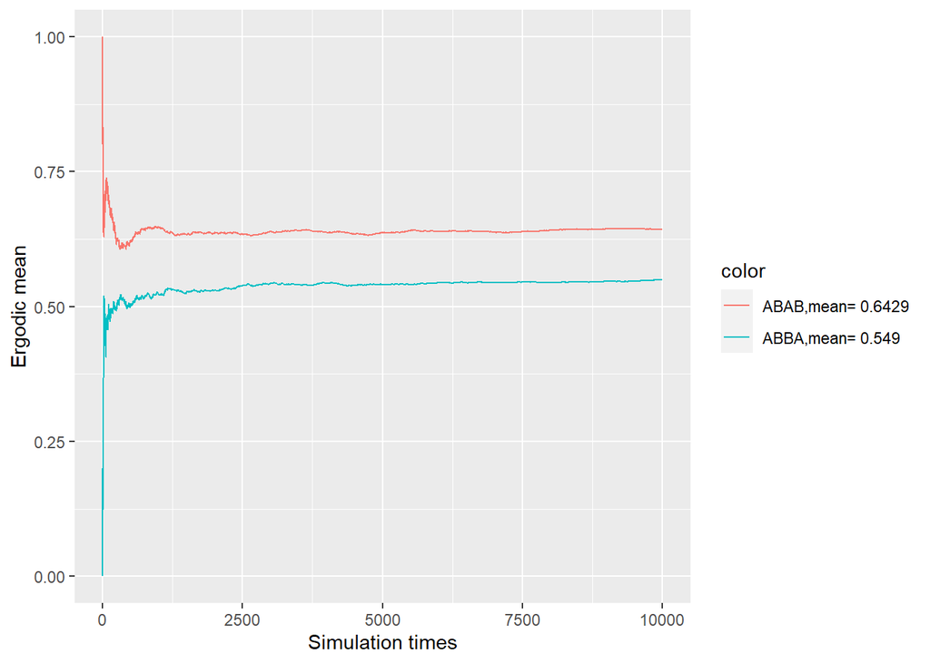

```r
y1 <- accumulate(r1,`+`)/(1:n)
y2 <- accumulate(r2,`+`)/(1:n)
tibble(x=1:n,y1=y1,y2=y2) %>%
  ggplot(aes(x=x))+
  geom_line(aes(y=y1,color=paste("ABAB,mean=",y1[[n]])))+
  geom_line(aes(y=y2,color=paste("ABBA,mean=",y2[[n]])))+
  labs(color="color",x="Simulation times",y="Ergodic mean")
```

封装成为函数：

```r
pk.sim.3 <- function(n=10000,p.A=0.7,q.B=0.68,delta=0.05,alpha=0.05){
  ## 定义一些函数

  # 传入状态三元组
  pk.end <- function(s){
    # 前三轮3-0
    if(s[[1]]==3 & abs(s[[3]]-s[[2]])==3) return(TRUE)
    # 前四轮分差大于1
    if(s[[1]]==4 & abs(s[[3]]-s[[2]])>1) return(TRUE)
    # 后面的所有轮次只要比分不同就结束
    if(s[[1]]>4 & s[[3]]!=s[[2]]) return(TRUE)

    # 其余一律未结束
    return(FALSE)
  }

  # 状态转移
  pk.AtoB <- function(s){
    p <- runif(2)
    n <- s[[2]]-s[[3]]
    if(p[[1]]<p.A+delta+n*alpha){
      s[[2]]<- s[[2]]+1
      if(p[[2]]<q.B-(n+1)*alpha) s[[3]] <- s[[3]]+1
    }else{
      if(p[[2]]<q.B+delta-n*alpha) s[[3]] <- s[[3]]+1
    }
    s[[1]] <- s[[1]]+1
    s
  }
  pk.BtoA <- function(s){
    p <- runif(2)
    n <- s[[2]]-s[[3]]
    if(p[[1]]<q.B+delta-n*alpha){
      s[[3]]<- s[[3]]+1
      if(p[[2]]<p.A+(n-1)*alpha) s[[2]] <- s[[2]]+1
    }else{
      if(p[[2]]<p.A+delta+n*alpha) s[[2]] <- s[[2]]+1
    }
    s[[1]] <- s[[1]]+1
    s
  }

  # 单次模拟
  pk.ABAB <- function(){
    s <- c(0,0,0)  # 初始化状态
    while (!pk.end(s)) {
      # A队先罚
      s <- pk.AtoB(s)
    }
    return(s[[2]]>s[[3]])
  }
  pk.ABBA <- function(){
    s <- c(0,0,0)  # 初始化状态
    while (!pk.end(s)) {
      # A队先罚
      if(s[[1]]%%2==0) s <- pk.AtoB(s)
      else s <- pk.BtoA(s)
    }
    return(s[[2]]>s[[3]])
  }

  # 多次模拟
  r1 <- vector("logical",n)
  r2 <- vector("logical",n)
  for (i in 1:n) {
    r1[[i]] <- pk.ABAB()
    r2[[i]] <- pk.ABBA()
  }

  return(list(m1=mean(r1),m2=mean(r2)))

}
```

## 3.3 模拟实验探讨

接下来我们考虑模拟结果跟$\Delta$、$\alpha$的关系。

### 3.3.1 离散化参数模拟

先假设一些参数$p_A=0.7,q_B=0.68$.然后取不同的$\Delta$跟$\alpha$，看看对最终的A队胜率的影响。

离散化取不同的$\Delta$跟$\alpha$：

```r
delta <- seq(0,0.2,0.01)
alpha <- seq(0,by = 0.02,length.out = 5)
```

对不同的参数进行模拟：

```r
tb4 <- crossing(delta,alpha)
a <- pmap(tb4,pk.sim.3)
tb4$m1 <- map_dbl(a,"m1")
tb4$m2 <- map_dbl(a,"m2")
```

绘图：

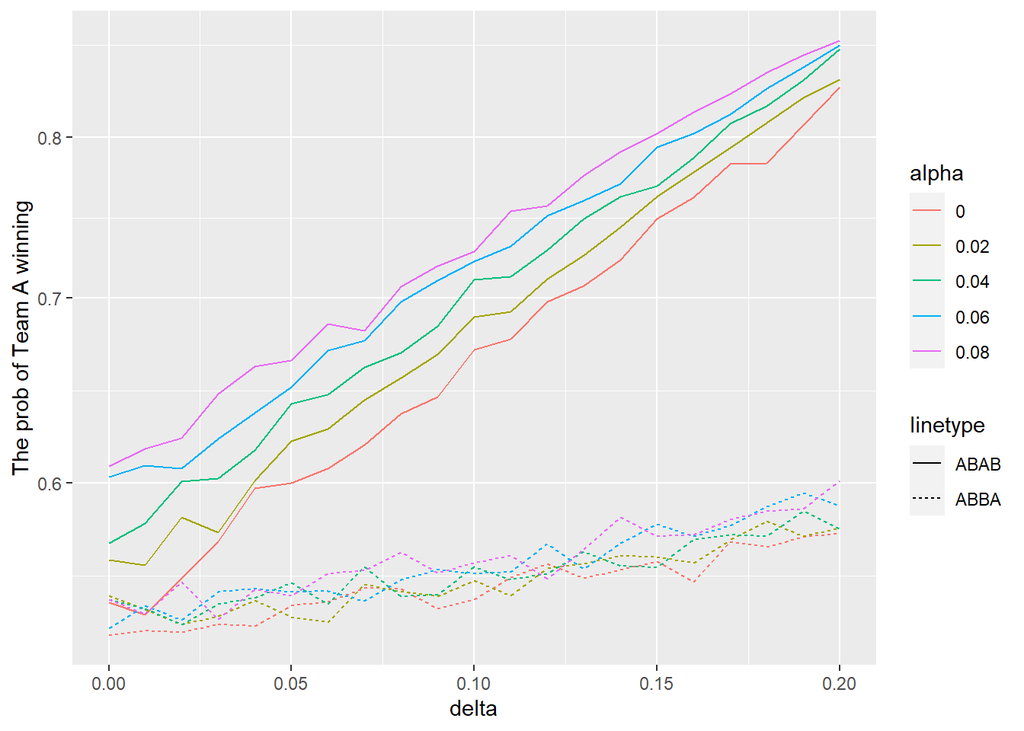

```r
tb4 %>%
  mutate(alpha = factor(alpha)) %>%
  ggplot()+
  geom_line(aes(delta,m1,group=alpha,color=alpha,linetype="ABAB"))+
  geom_line(aes(delta,m2,group=alpha,color=alpha,linetype="ABBA"))+
  scale_y_continuous(trans = "log10",
                     breaks = seq(0.4,0.8,0.1))+
  labs(y="The prob of Team A winning")
```

由上图可以看到，当无先手优势跟领先优势下，也即是起点处，两种规则的A队胜率几乎一致，随着$\Delta$或者$\alpha$的增大，两种规则下的A队胜率都一定程度上增大，但是显然ABBA规则下的增大幅度更小，意味着对先手优势跟领先优势的包容性更强，也即是更公平。

也就是说，假设存在先手优势或者领先优势，那么ABBA规则依旧能够更好地维持两队的公平。

接下来看看对于几个不同的$p_A,q_B$组合的变化情况。

```r
delta <- seq(0,0.2,0.01)
alpha <- seq(0,by = 0.02,length.out = 5)
p.A <- c(0.68,0.7,0.72)
q.B <- c(0.68,0.7,0.72)

tb5 <- crossing(p.A,q.B,delta,alpha)
a <- pmap(tb5,pk.sim.3)
tb5$m1 <- map_dbl(a,"m1")
tb5$m2 <- map_dbl(a,"m2")
```

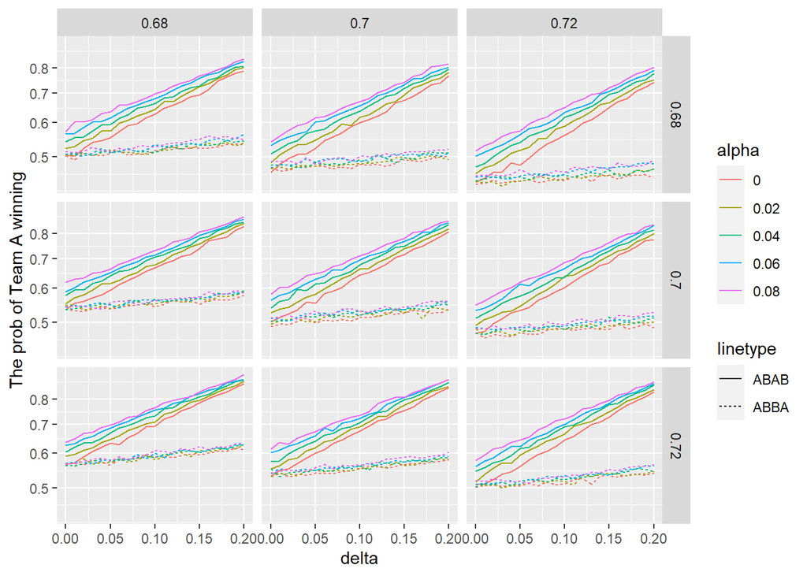

```r
tb5 %>%
  mutate(alpha = factor(alpha)) %>%
  ggplot()+
  geom_line(aes(delta,m1,group=alpha,color=alpha,linetype="ABAB"))+
  geom_line(aes(delta,m2,group=alpha,color=alpha,linetype="ABBA"))+
  scale_y_continuous(trans = 'log10',breaks = seq(0.4,0.8,0.1))+
  labs(y="The prob of Team A winning")+
  facet_grid(p.A~q.B)
```

`p.A`表示每一行，`q.B`表示每一列。可以看到，每个图像的形状与先前差别不大。`q.B`固定，随着`p.A`的增大，A队胜率上移，同理也有，`p.A`固定，随着`q.B`的增大，B队胜率上移，也即是球队的点球固定水平越高，更有可能获胜。观察一下对角线，当$p_A=q_B$时，无先手优势跟领先优势下两种规则的A队胜率都在0.5附近，与直觉一致。

可以猜想一下，`p.A`与`q.B`的值不会影响图像的大致形状，只会影响起点（无先手优势跟领先优势）。

做出这样的猜想，是想说明，我们并不需要对参数$p_A,q_B$利用实际数据作出估计，仅利用我们上面的讨论即可得到ABBA比ABAB更公平的结论。

### 3.3.2 估计参数模拟

想了一会，还是估计一下参数$p_A,q_B$。在我看来，估计参数$p_A,q_B$主要有两个途径，一个是通过球队的点球数据估计球队的点球固定水平，二是通过球队球员的点球数据估计某场比赛球队的点球固定水平，我比较倾向于后者。

以2020年欧洲杯决赛意大利对英国的比赛为例，先看看两队的罚球球员，再利用这些球员的历史点球数据的均值（总进球/总点球）估计该球队的点球固定水平。

比赛中，意大利队先踢，罚球人员以此为：Berardi、Belotti、Bonucc、Bernardeschi、Jorginho；英格兰队后踢，罚球人员依次为：Kane、Maguire、Rashford、Sancho、Saka。数据来源是：https://www.transfermarkt.com/ ，但有个小问题就是这里面的球员历史点球数据只包括常规时间的点球，不包括点球大战的点球数据。下面通过他们的历史点球数据来估计球队点球固定水平：

```r
# 意大利
Italy.scored <- c(35,31,2,11,29)  # 各个球员罚进数据
Italy.missed <- c(7,8,0,1,5)  # 各个球员罚丢数据
p.Italy <- sum(Italy.scored)/sum(Italy.scored+Italy.missed)

# 英格兰
Eng.scored <- c(45,0,15,10,2)
Eng.missed <- c(8,0,2,1,1)
p.Eng <- sum(Eng.scored)/sum(Eng.scored+Eng.missed)

cat("点球固定水平，意大利：",p.Italy,"，英国：",p.Eng)
```

```
## 点球固定水平，意大利： 0.8372093 ，英国： 0.8571429
```

利用该参数以及离散化其余参数进行模拟实验：

```r
delta <- seq(0,0.2,0.01)
alpha <- seq(0,by = 0.02,length.out = 5)
p.A <- p.Italy
q.B <- p.Eng
tb8 <- crossing(p.A,q.B,delta,alpha)
a <- pmap(tb8,pk.sim.3)
tb8$m1 <- map_dbl(a,"m1")
tb8$m2 <- map_dbl(a,"m2")
```

绘图：

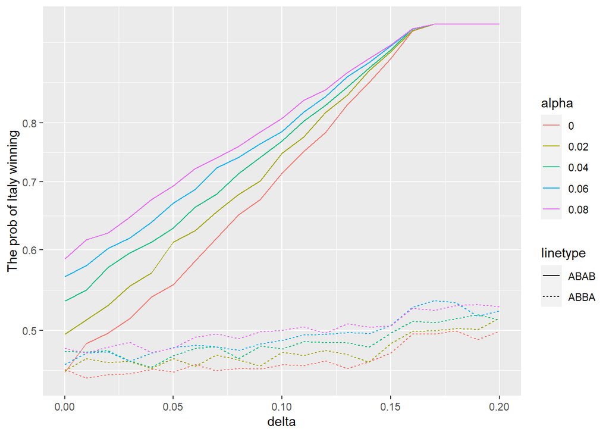

```r
tb8 %>%
  mutate(alpha = factor(alpha)) %>%
  ggplot()+
  geom_line(aes(delta,m1,group=alpha,color=alpha,linetype="ABAB"))+
  geom_line(aes(delta,m2,group=alpha,color=alpha,linetype="ABBA"))+
  scale_y_continuous(trans = 'log10',breaks = seq(0.4,0.8,0.1))+
  labs(y="The prob of Italy winning")
```

上图表明了，假设先手优势跟领先优势存在，那么随着两者的增大，ABAB规则下意大利队胜率会急剧上升，而ABBA规则下则比较平稳。所以总的来说，ABBA要比ABAB要更公平一下。

# 4 球员点球顺序探讨

## 4.1 问题

前面考虑的是整个球队的整体水平，接下来考虑各个球员的具体水平。假设对方球队的点球水平是个标量值（即类似于前面的$p_A,q_B$），己方球队的点球水平为向量（即每个队员的点球水平），己方不同的球员点球顺序对最终的结果是否会有影响？有怎样的影响？

## 4.2 模型建立

为了简化问题，这里只考虑5轮的情况（有关点球大战的具体规则点击[这里](https://baike.baidu.com/item/%E7%82%B9%E7%90%83%E5%86%B3%E8%83%9C/12728545)），然后剔除5轮后平局情况的数据计算球队点球胜率。

定义模拟函数：

```r
pk.sim.4 <- function(n=10000,p.A=rep(0.7,5),q.B=rep(0.68,5),
                     delta=0.05,alpha=0.05){
  ## 定义一些函数

  # 传入状态三元组
  pk.end <- function(s){
    # 前三轮3-0
    if(s[[1]]==3 & abs(s[[3]]-s[[2]])==3) return(TRUE)
    # 前四轮分差大于1
    if(s[[1]]==4 & abs(s[[3]]-s[[2]])>1) return(TRUE)
    # 踢到第5轮就结束
    if(s[[1]]==5) return(TRUE)

    # 其余一律未结束
    return(FALSE)
  }

  # 状态转移
  pk.AtoB <- function(s){
    s[[1]] <- s[[1]]+1
    p <- runif(2)
    n <- s[[2]]-s[[3]]
    if(p[[1]]<(p.A[s[1]]+delta+n*alpha)){
      s[[2]]<- s[[2]]+1
      if(p[[2]]<(q.B[s[1]]-(n+1)*alpha)) s[[3]] <- s[[3]]+1
    }else{
      if(p[[2]]<(q.B[s[1]]+delta-n*alpha)) s[[3]] <- s[[3]]+1
    }
    s
  }
  pk.BtoA <- function(s){
    s[[1]] <- s[[1]]+1
    p <- runif(2)
    n <- s[[2]]-s[[3]]
    if(p[[1]]<(q.B[s[1]]+delta-n*alpha)){
      s[[3]]<- s[[3]]+1
      if(p[[2]]<(p.A[s[1]]+(n-1)*alpha)) s[[2]] <- s[[2]]+1
    }else{
      if(p[[2]]<(p.A[s[1]]+delta+n*alpha)) s[[2]] <- s[[2]]+1
    }
    s
  }

  # 单次模拟
  # 输出：
  # 1：A队胜
  # 0：5轮打平
  # -1：A队负
  pk.ABAB <- function(){
    s <- c(0,0,0)  # 初始化状态
    while (!pk.end(s)) {
      # A队先罚
      s <- pk.AtoB(s)
      #print(s)
    }
    if(s[[2]]>s[[3]]) return(1)
    else if(s[[2]]==s[[3]]) return(0)
    else return(-1)
  }
  pk.ABBA <- function(){
    s <- c(0,0,0)  # 初始化状态
    while (!pk.end(s)) {
      # A队先罚
      if(s[[1]]%%2==0) s <- pk.AtoB(s)
      else s <- pk.BtoA(s)
      #print(s)
    }
    if(s[[2]]>s[[3]]) return(1)
    else if(s[[2]]==s[[3]]) return(0)
    else return(-1)
  }

  # 多次模拟
  r1 <- vector("integer",n)
  r2 <- vector("integer",n)
  for (i in 1:n) {
    r1[[i]] <- pk.ABAB()
    r2[[i]] <- pk.ABBA()
  }

  m1 <- sum(r1==1)/(n-sum(r1==0))
  m2 <- sum(r2==1)/(n-sum(r2==0))

  return(list(m1=m1,m2=m2))

}
```

## 4.3 模拟实验探讨

### 4.3.1 固定$p_A$

固定$p_A=0.7$，取$q_B=0.5,0.6,0.7,0.8,0.9$。其余参数取$\Delta=0.05,\alpha=0.02$，每轮模拟20000次。

**PS:**想要返回向量的全排列，可以利用`gtools`包的`permutations`函数。

```r
permutations(3,3,1:3)
```

```
##      [,1] [,2] [,3]
## [1,]    1    2    3
## [2,]    1    3    2
## [3,]    2    1    3
## [4,]    2    3    1
## [5,]    3    1    2
## [6,]    3    2    1
```

```r
q.B <- c(0.5,0.6,0.7,0.8,0.9)
per.qB <- as.data.frame(t(permutations(5,5,q.B)))
tb9 <- as_tibble(permutations(5,5,q.B))
```

```r
p.A <- rep(0.7,5)
a <- map(per.qB,pk.sim.4,n=20000,
             p.A=p.A,delta=0.05,alpha=0.02)
```

```r
tb9$m1 <- map_dbl(a,"m1")
tb9$m2 <- map_dbl(a,"m2")
tb9 <- tb9 %>%
  mutate(m1=1-m1,m2=1-m2)
```

不同规则下，B队不同的点球顺序对B队胜率的影响：

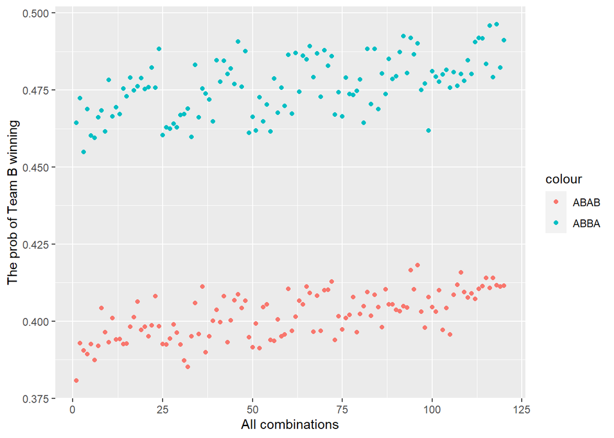

```r
tb9 %>%
  mutate(n=1:n()) %>%
  ggplot()+
  geom_point(aes(n,m1,color="ABAB"))+
  geom_point(aes(n,m2,color="ABBA"))+
  labs(x="All combinations",y="The prob of Team B winning")
```

可以看到，两种规则对B队不同点球顺序的胜率的影响差不多。

### 4.3.2 固定$q_B$

类似地，我们同样可以固定$q_B=0.7$，取$p_A=0.5,0.6,0.7,0.8,0.9$。其余参数取$\Delta=0.05,\alpha=0.02$，每轮模拟20000次。

```r
p.A <- c(0.5,0.6,0.7,0.8,0.9)
per.pA <- as.data.frame(t(permutations(5,5,p.A)))
tb10 <- as_tibble(permutations(5,5,p.A))
q.B <- rep(0.7,5)
a <- map(per.pA,pk.sim.4,n=20000,
             q.B=q.B,delta=0.05,alpha=0.02)
```

```r
tb10$m1 <- map_dbl(a,"m1")
tb10$m2 <- map_dbl(a,"m2")
```

不同规则下，A队不同的点球顺序对A队胜率的影响：

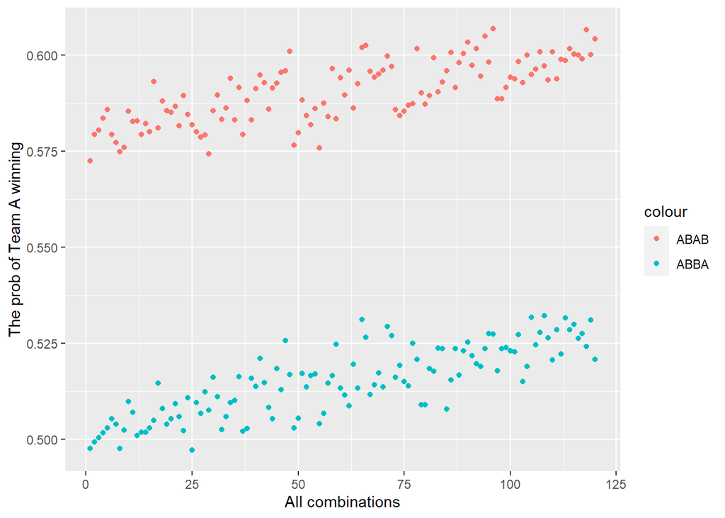

```r
tb10 %>%
  mutate(n=1:n()) %>%
  ggplot()+
  geom_point(aes(n,m1,color="ABAB"))+
  geom_point(aes(n,m2,color="ABBA"))+
  labs(x="All combinations",y="The prob of Team A winning")
```

类似的结果，两种规则对B队不同点球顺序的胜率的影响差不多。

### 4.3.3 两者结合

前面分别探讨了固定$p_A,q_B$的情况，对应的现实情形就是，已知对方的整体水平（$p_A$或$q_B$），以及自己先踢还是后踢（A队或B队），选择己方不同的球员点球顺序对最终胜率的影响。但是，在点球大战规则中，我们是要先确定己方球员点球顺序再通过抛硬币的方式决定AB队，这种情况下，我们假设自己有0.5的概率是A队或B队（毕竟是通过抛硬币的方式决定），即有0.5的概率处于上面两种情况的一种，所以我们的最终胜率可以通过上面结果的均值得到各个规则下得到。

这时候所对应的现实情形就是，我们了解到对方球队的点球整体水平为0.7，己方的点球手的水平分别为$(0.5,0.6,0.7,0.8,0.9)$，考虑己方不同的球员点球上场顺序对最终胜率的影响怎么样。

```r
tb11 <- tb10 %>%
  mutate(m1=(m1+tb9$m1)/2,m2=(m2+tb9$m2)/2)
```

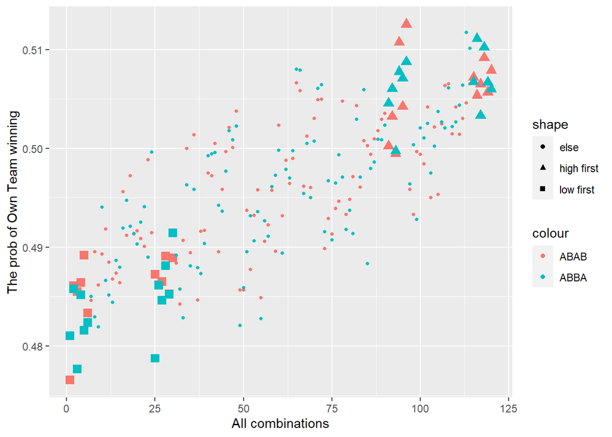

```r
tb11 %>%
  mutate(n=1:n()) %>%
  mutate(shape_ind = case_when(
    V1==0.5 & V2==0.6 ~ "low first",
    V1==0.6 & V2==0.5 ~ "low first",
    V1==0.9 & V2==0.8 ~ "high first",
    V1==0.8 & V2==0.9 ~ "high first",
    TRUE ~ "else"
  )) %>%
  mutate(size_ind = case_when(
    shape_ind=="low first" ~ 3,
    shape_ind=="high first" ~ 3,
    TRUE ~ 1
  )) %>%
  ggplot()+
  geom_point(aes(n,m1,color="ABAB",shape=shape_ind,size=size_ind))+
  geom_point(aes(n,m2,color="ABBA",shape=shape_ind,size=size_ind))+
  scale_size_identity()+
  labs(x="All combinations",y="The prob of Own Team winning",shape="shape")
```

图像跟上面的差不多，它表明了两种规则对B队不同点球顺序的胜率的影响差不多。下面探讨一下极端值，即什么样的点球顺序会使胜率下降，什么样的点球顺序会使胜率上升。

先考虑现行的ABAB规则，胜率最低和最高的5个组合共10个组合如下：

```r
tb11 %>%
  slice_min(m1,n=5) %>%
  select(-m2)
```

```
## # A tibble: 5 x 6
##      V1    V2    V3    V4    V5    m1
##   <dbl> <dbl> <dbl> <dbl> <dbl> <dbl>
## 1   0.5   0.6   0.7   0.8   0.9 0.477
## 2   0.5   0.6   0.9   0.8   0.7 0.483
## 3   0.6   0.7   0.5   0.9   0.8 0.484
## 4   0.5   0.7   0.6   0.8   0.9 0.485
## 5   0.6   0.8   0.5   0.7   0.9 0.485
```

```r
tb11 %>%
  slice_max(m1,n=5) %>%
  select(-m2)
```

```
## # A tibble: 5 x 6
##      V1    V2    V3    V4    V5    m1
##   <dbl> <dbl> <dbl> <dbl> <dbl> <dbl>
## 1   0.8   0.9   0.7   0.6   0.5 0.513
## 2   0.8   0.9   0.6   0.7   0.5 0.511
## 3   0.9   0.8   0.6   0.7   0.5 0.509
## 4   0.9   0.8   0.7   0.6   0.5 0.508
## 5   0.9   0.8   0.5   0.6   0.7 0.507
```

通过上面这个表，我们可以大致猜测，**点球水平高的球员先罚，点球水平低的球员后罚，能够获得更高的胜率，而相反的做法会得到更低的胜率**。所以可以对球队给出建议，将点球水平较高的球员排在前面罚球，点球水平较低的球员排在后面罚球，

对于ABBA规则，同样地做法：

```r
tb11 %>%
  slice_min(m2,n=5) %>%
  select(-m1)
```

```
## # A tibble: 5 x 6
##      V1    V2    V3    V4    V5    m2
##   <dbl> <dbl> <dbl> <dbl> <dbl> <dbl>
## 1   0.5   0.6   0.8   0.7   0.9 0.478
## 2   0.6   0.5   0.7   0.8   0.9 0.479
## 3   0.5   0.6   0.7   0.8   0.9 0.481
## 4   0.5   0.6   0.9   0.7   0.8 0.482
## 5   0.5   0.7   0.8   0.6   0.9 0.482
```

```r
tb11 %>%
  slice_max(m2,n=5) %>%
  select(-m1)
```

```
## # A tibble: 5 x 6
##      V1    V2    V3    V4    V5    m2
##   <dbl> <dbl> <dbl> <dbl> <dbl> <dbl>
## 1   0.9   0.7   0.8   0.5   0.6 0.512
## 2   0.9   0.8   0.5   0.7   0.6 0.511
## 3   0.9   0.8   0.6   0.7   0.5 0.510
## 4   0.9   0.7   0.8   0.6   0.5 0.510
## 5   0.8   0.9   0.7   0.6   0.5 0.509
```

算是跟ABAB规则差别不大吧，得到的结论也差不多。

### 4.3.4 延展

前面讨论了对方球队点球水平为0.7，己方球队点球平均意义下为0.7的情况。接下来还可以考虑其他情况，主要为4种：对方球队点球水平大于或小于己方球队点球平均水平、对方球队点球水平一致地大于或小于己方球队点球水平。

先将上面实现的第一种情况抽象为函数：

```r
# our.p 我方球员点球水平向量
# other.p 对方球员点球水平向量
pk.order.sim <- function(n=20000,our.p=rep(0.7,5),other.p=rep(0.68,5),
                     delta=0.05,alpha=0.02)
{
  per.our <- as.data.frame(t(permutations(5,5,our.p)))
  tb1 <- as_tibble(permutations(5,5,our.p))
  # 我方是A队
  a <- map(per.our,pk.sim.4,n=n,
           q.B=other.p,delta=delta,alpha=alpha)
  # 我方是B队
  b <- map(per.our,pk.sim.4,n=n,
           p.A=other.p,delta=delta,alpha=alpha)
  tb1$m1 <- (map_dbl(a,"m1")+1-map_dbl(b,"m1"))/2
  tb1$m2 <- (map_dbl(a,"m2")+1-map_dbl(b,"m2"))/2
  tb1
}
```

```r
a <- pk.order.sim(our.p = c(0.5,0.6,0.7,0.8,0.9),other.p = rep(0.7,5))
```

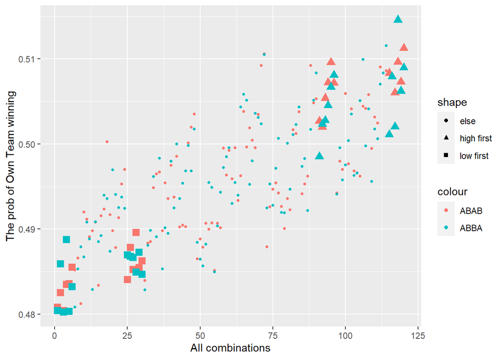

```r
a %>%
  mutate(n=1:n()) %>%
  mutate(shape_ind = case_when(
    V1==0.5 & V2==0.6 ~ "low first",
    V1==0.6 & V2==0.5 ~ "low first",
    V1==0.9 & V2==0.8 ~ "high first",
    V1==0.8 & V2==0.9 ~ "high first",
    TRUE ~ "else"
  )) %>%
  mutate(size_ind = case_when(
    shape_ind=="low first" ~ 3,
    shape_ind=="high first" ~ 3,
    TRUE ~ 1
  )) %>%
  ggplot()+
  geom_point(aes(n,m1,color="ABAB",shape=shape_ind,size=size_ind))+
  geom_point(aes(n,m2,color="ABBA",shape=shape_ind,size=size_ind))+
  scale_size_identity()+
  labs(x="All combinations",y="The prob of Own Team winning",shape="shape")
```

#### 4.3.4.1 情况1

对方球队点球水平大于己方球队点球平均水平，不妨设对方球队点球水平为0.8，己方为$(0.5,0.6,0.7,0.8,0.9)$。

绘图：

```r
a <- pk.order.sim(our.p = c(0.5,0.6,0.7,0.8,0.9),other.p = rep(0.8,5))
```

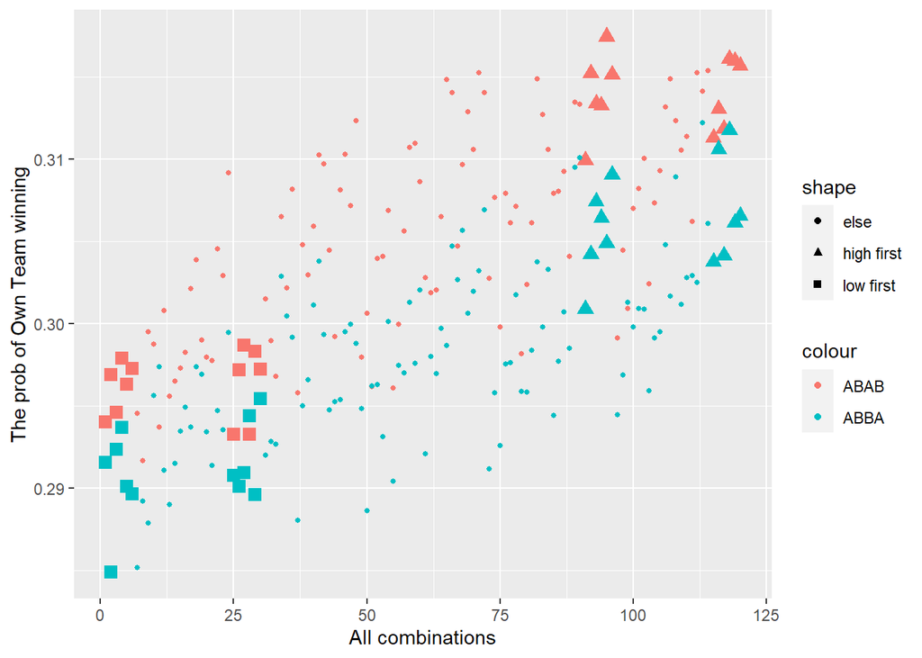

```r
a %>%
  mutate(n=1:n()) %>%
  mutate(shape_ind = case_when(
    V1==0.5 & V2==0.6 ~ "low first",
    V1==0.6 & V2==0.5 ~ "low first",
    V1==0.9 & V2==0.8 ~ "high first",
    V1==0.8 & V2==0.9 ~ "high first",
    TRUE ~ "else"
  )) %>%
  mutate(size_ind = case_when(
    shape_ind=="low first" ~ 3,
    shape_ind=="high first" ~ 3,
    TRUE ~ 1
  )) %>%
  ggplot()+
  geom_point(aes(n,m1,color="ABAB",shape=shape_ind,size=size_ind))+
  geom_point(aes(n,m2,color="ABBA",shape=shape_ind,size=size_ind))+
  scale_size_identity()+
  labs(x="All combinations",y="The prob of Own Team winning",shape="shape")
```

取极端值对应组合：

ABAB规则：

```r
a %>%
  slice_min(m1,n=5) %>%
  select(-m2)
```

```
## # A tibble: 5 x 6
##      V1    V2    V3    V4    V5    m1
##   <dbl> <dbl> <dbl> <dbl> <dbl> <dbl>
## 1   0.5   0.7   0.6   0.9   0.8 0.292
## 2   0.6   0.5   0.7   0.8   0.9 0.293
## 3   0.6   0.5   0.8   0.9   0.7 0.293
## 4   0.5   0.7   0.9   0.6   0.8 0.294
## 5   0.5   0.6   0.7   0.8   0.9 0.294
```

```r
a %>%
  slice_max(m1,n=5) %>%
  select(-m2)
```

```
## # A tibble: 5 x 6
##      V1    V2    V3    V4    V5    m1
##   <dbl> <dbl> <dbl> <dbl> <dbl> <dbl>
## 1   0.8   0.9   0.7   0.5   0.6 0.317
## 2   0.9   0.8   0.6   0.7   0.5 0.316
## 3   0.9   0.8   0.7   0.5   0.6 0.316
## 4   0.9   0.8   0.7   0.6   0.5 0.316
## 5   0.9   0.7   0.8   0.6   0.5 0.315
```

ABAB规则：

```r
a %>%
  slice_min(m2,n=5) %>%
  select(-m1)
```

```
## # A tibble: 5 x 6
##      V1    V2    V3    V4    V5    m2
##   <dbl> <dbl> <dbl> <dbl> <dbl> <dbl>
## 1   0.5   0.6   0.7   0.9   0.8 0.285
## 2   0.5   0.7   0.6   0.8   0.9 0.285
## 3   0.5   0.7   0.8   0.6   0.9 0.288
## 4   0.6   0.8   0.5   0.7   0.9 0.288
## 5   0.7   0.5   0.6   0.9   0.8 0.289
```

```r
a %>%
  slice_max(m2,n=5) %>%
  select(-m1)
```

```
## # A tibble: 5 x 6
##      V1    V2    V3    V4    V5    m2
##   <dbl> <dbl> <dbl> <dbl> <dbl> <dbl>
## 1   0.9   0.7   0.8   0.5   0.6 0.312
## 2   0.9   0.8   0.6   0.7   0.5 0.312
## 3   0.9   0.8   0.5   0.7   0.6 0.311
## 4   0.8   0.7   0.9   0.6   0.5 0.310
## 5   0.8   0.7   0.9   0.5   0.6 0.310
```

可以看到，当对方球队点球水平大于己方球队点球平均水平，但是己方球队有球员点球水平高于或等于对方球队时，应当把他们尽量安排靠前踢，能提高球队点球胜率。

#### 4.3.4.2 情况2

对方球队点球水平小于于己方球队点球平均水平，不妨设对方球队点球水平为0.6，己方为$(0.5,0.6,0.7,0.8,0.9)$。

绘图：

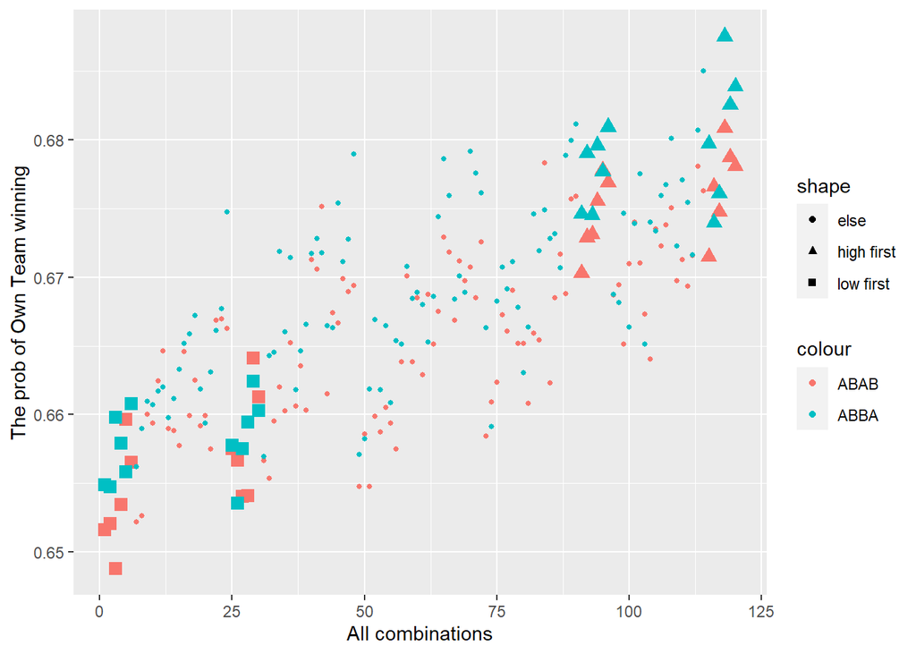

```r
a <- pk.order.sim(our.p = c(0.5,0.6,0.7,0.8,0.9),other.p = rep(0.6,5))

a %>%
  mutate(n=1:n()) %>%
  mutate(shape_ind = case_when(
    V1==0.5 & V2==0.6 ~ "low first",
    V1==0.6 & V2==0.5 ~ "low first",
    V1==0.9 & V2==0.8 ~ "high first",
    V1==0.8 & V2==0.9 ~ "high first",
    TRUE ~ "else"
  )) %>%
  mutate(size_ind = case_when(
    shape_ind=="low first" ~ 3,
    shape_ind=="high first" ~ 3,
    TRUE ~ 1
  )) %>%
  ggplot()+
  geom_point(aes(n,m1,color="ABAB",shape=shape_ind,size=size_ind))+
  geom_point(aes(n,m2,color="ABBA",shape=shape_ind,size=size_ind))+
  scale_size_identity()+
  labs(x="All combinations",y="The prob of Own Team winning",shape="shape")
```

取极端值对应组合：

ABAB规则：

```r
a %>%
  slice_min(m1,n=5) %>%
  select(-m2)
```

```
## # A tibble: 5 x 6
##      V1    V2    V3    V4    V5    m1
##   <dbl> <dbl> <dbl> <dbl> <dbl> <dbl>
## 1   0.5   0.6   0.8   0.7   0.9 0.649
## 2   0.5   0.6   0.7   0.8   0.9 0.652
## 3   0.5   0.6   0.7   0.9   0.8 0.652
## 4   0.5   0.7   0.6   0.8   0.9 0.652
## 5   0.5   0.7   0.6   0.9   0.8 0.653
```

```r
a %>%
  slice_max(m1,n=5) %>%
  select(-m2)
```

```
## # A tibble: 5 x 6
##      V1    V2    V3    V4    V5    m1
##   <dbl> <dbl> <dbl> <dbl> <dbl> <dbl>
## 1   0.9   0.8   0.6   0.7   0.5 0.681
## 2   0.9   0.8   0.7   0.5   0.6 0.679
## 3   0.8   0.6   0.9   0.7   0.5 0.678
## 4   0.9   0.8   0.7   0.6   0.5 0.678
## 5   0.9   0.7   0.8   0.5   0.6 0.678
```

ABAB规则：

```r
a %>%
  slice_min(m2,n=5) %>%
  select(-m1)
```

```
## # A tibble: 5 x 6
##      V1    V2    V3    V4    V5    m2
##   <dbl> <dbl> <dbl> <dbl> <dbl> <dbl>
## 1   0.6   0.5   0.7   0.9   0.8 0.654
## 2   0.5   0.6   0.7   0.9   0.8 0.655
## 3   0.5   0.6   0.7   0.8   0.9 0.655
## 4   0.5   0.6   0.9   0.7   0.8 0.656
## 5   0.5   0.7   0.6   0.8   0.9 0.656
```

```r
a %>%
  slice_max(m2,n=5) %>%
  select(-m1)
```

```
## # A tibble: 5 x 6
##      V1    V2    V3    V4    V5    m2
##   <dbl> <dbl> <dbl> <dbl> <dbl> <dbl>
## 1   0.9   0.8   0.6   0.7   0.5 0.688
## 2   0.9   0.7   0.8   0.6   0.5 0.685
## 3   0.9   0.8   0.7   0.6   0.5 0.684
## 4   0.9   0.8   0.7   0.5   0.6 0.683
## 5   0.8   0.7   0.9   0.6   0.5 0.681
```

结论一致。

#### 4.3.4.3 情况3

对方球队点球水平一致地大于己方球队点球水平，不妨设对方球队点球水平为0.85，己方为$(0.4,0.5,0.6,0.7,0.8)$。

绘图：

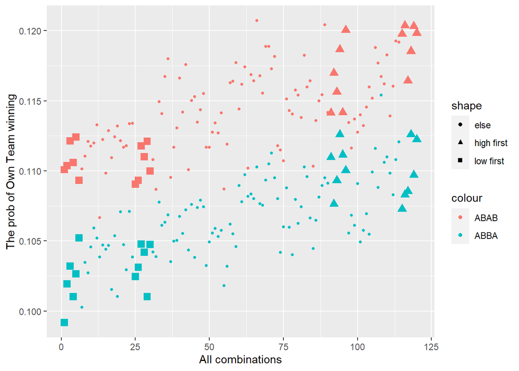

```r
a <- pk.order.sim(our.p = c(0.4,0.5,0.6,0.7,0.8),other.p = rep(0.85,5))

a %>%
  mutate(n=1:n()) %>%
  mutate(shape_ind = case_when(
    V1==0.4 & V2==0.5 ~ "low first",
    V1==0.5 & V2==0.4 ~ "low first",
    V1==0.7 & V2==0.8 ~ "high first",
    V1==0.8 & V2==0.7 ~ "high first",
    TRUE ~ "else"
  )) %>%
  mutate(size_ind = case_when(
    shape_ind=="low first" ~ 3,
    shape_ind=="high first" ~ 3,
    TRUE ~ 1
  )) %>%
  ggplot()+
  geom_point(aes(n,m1,color="ABAB",shape=shape_ind,size=size_ind))+
  geom_point(aes(n,m2,color="ABBA",shape=shape_ind,size=size_ind))+
  scale_size_identity()+
  labs(x="All combinations",y="The prob of Own Team winning",shape="shape")
```

取极端值对应组合：

ABAB规则：

```r
a %>%
  slice_min(m1,n=5) %>%
  select(-m2)
```

```
## # A tibble: 5 x 6
##      V1    V2    V3    V4    V5    m1
##   <dbl> <dbl> <dbl> <dbl> <dbl> <dbl>
## 1   0.4   0.7   0.5   0.6   0.8 0.107
## 2   0.5   0.6   0.4   0.8   0.7 0.109
## 3   0.6   0.5   0.4   0.7   0.8 0.109
## 4   0.5   0.4   0.6   0.7   0.8 0.109
## 5   0.4   0.5   0.8   0.7   0.6 0.109
```

```r
a %>%
  slice_max(m1,n=5) %>%
  select(-m2)
```

```
## # A tibble: 5 x 6
##      V1    V2    V3    V4    V5    m1
##   <dbl> <dbl> <dbl> <dbl> <dbl> <dbl>
## 1   0.6   0.7   0.8   0.5   0.4 0.121
## 2   0.7   0.6   0.8   0.4   0.5 0.120
## 3   0.8   0.7   0.4   0.6   0.5 0.120
## 4   0.8   0.7   0.6   0.4   0.5 0.120
## 5   0.7   0.8   0.6   0.5   0.4 0.120
```

ABAB规则：

```r
a %>%
  slice_min(m2,n=5) %>%
  select(-m1)
```

```
## # A tibble: 5 x 6
##      V1    V2    V3    V4    V5     m2
##   <dbl> <dbl> <dbl> <dbl> <dbl>  <dbl>
## 1   0.4   0.5   0.6   0.7   0.8 0.0992
## 2   0.4   0.6   0.5   0.7   0.8 0.100
## 3   0.5   0.4   0.8   0.6   0.7 0.101
## 4   0.4   0.5   0.7   0.8   0.6 0.101
## 5   0.4   0.8   0.5   0.6   0.7 0.101
```

```r
a %>%
  slice_max(m2,n=5) %>%
  select(-m1)
```

```
## # A tibble: 5 x 6
##      V1    V2    V3    V4    V5    m2
##   <dbl> <dbl> <dbl> <dbl> <dbl> <dbl>
## 1   0.8   0.5   0.7   0.6   0.4 0.115
## 2   0.7   0.8   0.5   0.6   0.4 0.113
## 3   0.8   0.7   0.5   0.6   0.4 0.113
## 4   0.8   0.7   0.6   0.5   0.4 0.112
## 5   0.8   0.6   0.7   0.5   0.4 0.112
```

结论一致。

#### 4.3.4.4 情况4

对方球队点球水平一致地小于己方球队点球水平，不妨设对方球队点球水平为0.45，己方为$(0.5,0.6,0.7,0.8,0.9)$。

绘图：

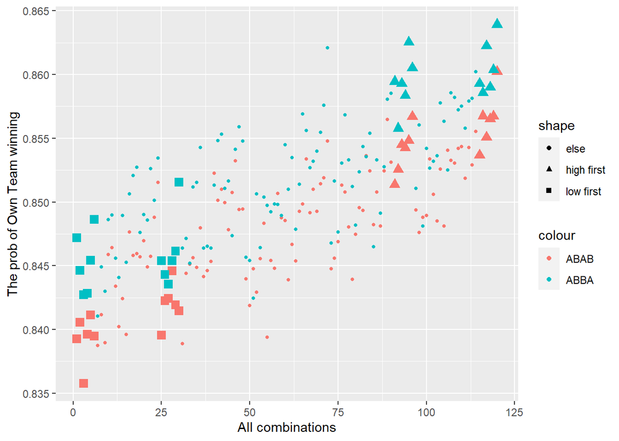

```r
a <- pk.order.sim(our.p = c(0.5,0.6,0.7,0.8,0.9),other.p = rep(0.45,5))

a %>%
  mutate(n=1:n()) %>%
  mutate(shape_ind = case_when(
    V1==0.5 & V2==0.6 ~ "low first",
    V1==0.6 & V2==0.5 ~ "low first",
    V1==0.9 & V2==0.8 ~ "high first",
    V1==0.8 & V2==0.9 ~ "high first",
    TRUE ~ "else"
  )) %>%
  mutate(size_ind = case_when(
    shape_ind=="low first" ~ 3,
    shape_ind=="high first" ~ 3,
    TRUE ~ 1
  )) %>%
  ggplot()+
  geom_point(aes(n,m1,color="ABAB",shape=shape_ind,size=size_ind))+
  geom_point(aes(n,m2,color="ABBA",shape=shape_ind,size=size_ind))+
  scale_size_identity()+
  labs(x="All combinations",y="The prob of Own Team winning",shape="shape")
```

取极端值对应组合：

ABAB规则：

```r
a %>%
  slice_min(m1,n=5) %>%
  select(-m2)
```

```
## # A tibble: 5 x 6
##      V1    V2    V3    V4    V5    m1
##   <dbl> <dbl> <dbl> <dbl> <dbl> <dbl>
## 1   0.5   0.6   0.8   0.7   0.9 0.836
## 2   0.5   0.7   0.6   0.8   0.9 0.839
## 3   0.6   0.7   0.5   0.8   0.9 0.839
## 4   0.5   0.7   0.8   0.6   0.9 0.839
## 5   0.5   0.6   0.7   0.8   0.9 0.839
```

```r
a %>%
  slice_max(m1,n=5) %>%
  select(-m2)
```

```
## # A tibble: 5 x 6
##      V1    V2    V3    V4    V5    m1
##   <dbl> <dbl> <dbl> <dbl> <dbl> <dbl>
## 1   0.9   0.8   0.7   0.6   0.5 0.860
## 2   0.9   0.8   0.5   0.7   0.6 0.857
## 3   0.9   0.8   0.7   0.5   0.6 0.857
## 4   0.8   0.9   0.7   0.6   0.5 0.857
## 5   0.9   0.8   0.6   0.7   0.5 0.857
```

ABAB规则：

```r
a %>%
  slice_min(m2,n=5) %>%
  select(-m1)
```

```
## # A tibble: 5 x 6
##      V1    V2    V3    V4    V5    m2
##   <dbl> <dbl> <dbl> <dbl> <dbl> <dbl>
## 1   0.5   0.7   0.6   0.8   0.9 0.841
## 2   0.7   0.5   0.8   0.6   0.9 0.842
## 3   0.5   0.6   0.8   0.7   0.9 0.843
## 4   0.5   0.6   0.8   0.9   0.7 0.843
## 5   0.5   0.7   0.8   0.6   0.9 0.843
```

```r
a %>%
  slice_max(m2,n=5) %>%
  select(-m1)
```

```
## # A tibble: 5 x 6
##      V1    V2    V3    V4    V5    m2
##   <dbl> <dbl> <dbl> <dbl> <dbl> <dbl>
## 1   0.9   0.8   0.7   0.6   0.5 0.864
## 2   0.8   0.9   0.7   0.5   0.6 0.863
## 3   0.9   0.8   0.6   0.5   0.7 0.862
## 4   0.7   0.9   0.8   0.6   0.5 0.862
## 5   0.8   0.9   0.7   0.6   0.5 0.861
```

结论一致。

#### 4.3.4.5 小结

不论什么情况，也即是对方球队的水平与己方球队相比如何，都应该尽可能把点球水平较高的球员安排在靠前上场，水平较低的球员安排在靠后上场，能比相反的做法提高大概0.02-0.04的胜率.